# Confidence Intervals

## Terms

Point Estimate is a single value calculated from a sample of data that is used to estimate the value of an unknown parameter of a population.

Confidence Interval is a range of values that likely contains the true population parameter with a certain level of confidence.

Level of Confidence is a probability that the confidence interval actually captures a true value.

# Before we discuss confidence intervals, we need to learn about bootstrapping 🥾

## Bootstrapping

This is a technique used to estimate the sampling distribution of a statistic by repeatedly re-sampling from the observed data with replacement

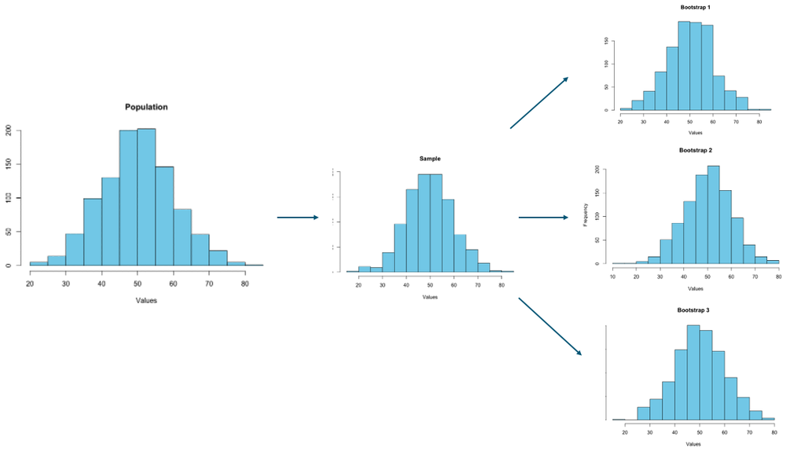

## Bootstrap Example

This is our sample.

$$(-5,0)*--*-*-*-*---(0,0)--\stackrel{\mu}{|}--*--*--*-*-- (5,0)$$

Then randomly pull 3 values, which becomes our data.

$$(-5,0)---*-----(0,0) \stackrel{\mu}{|}----*-----*-- (5,0)$$

Plot our mean then throw those values back in (i.e., replacement) and pull another 3.

$$(-5,0)--------(0,0)----*--*-\stackrel{\mu}{|}-*---- (5,0)$$

Plot that mean and repeat!

## Bootstrap Example

Eventually we will have tons of means (we only have 9 in our example here) but in reality we would have hundreds or even thousands huddled around a similar point on our number line.

$$(-5,0)-\stackrel{\mu}{|}----\stackrel{\mu}{|}---(0,0)---\stackrel{\mu}{|}-\stackrel{\mu}{|}-\stackrel{\mu}{|}-\stackrel{\mu}{|}-\stackrel{\mu}{|}-\stackrel{\mu}{|}---\stackrel{\mu}{|}- (5,0)$$

Once we have these, we have robust estimates of a true mean within a sample.

# Great, but what does this have to do with confidence intervals?

## Confidence Intervals

Well, when we bootstrapped we essentially created an empirical sampling distribution.

$$(-5,0)-\stackrel{\mu}{|}----\stackrel{\mu}{|}---(0,0)---\stackrel{\mu}{|}-\stackrel{\mu}{|}-\stackrel{\mu}{|}-\stackrel{\mu}{|}-\stackrel{\mu}{|}-\stackrel{\mu}{|}---\stackrel{\mu}{|}- (5,0)$$

And as a result we can identify the percentiles that corresponds to your desired confidence level.

These percentiles from the bootstrap replicates become the lower and upper bounds of what we will call a confidence interval.

## Confidence Intervals

Now that we have this sampling distribution we can calculate our 95% confidence interval.

Which simply means, we have a 95% certainty that our population mean will fall between the two red lines.

And 5% of the time, our population mean could fall outside of that zone.

$$(-5,0)-\stackrel{\mu}{|}--\stackrel{\mu}{|}---(0,0)---\color{red}\vert-\stackrel{\mu}{|}-\stackrel{\mu}{|}-\stackrel{\mu}{|}-\stackrel{\mu}{|}-\stackrel{\mu}{|}-\stackrel{\mu}{|}-\color{red}\vert--\stackrel{\mu}{|}- (5,0)$$

# Time for Math! 🧮

## Confidence Interval

$$\text{CI} = \bar{x} \pm z \frac{s}{\sqrt{n}}$$

$\bar{x}$ = sample mean

$z$ = confidence level

$s$ = sample standard deviation

$n$ = sample size

- Large sample are $\geq 30$
- Small samples are $<30$

## Confidence Levels

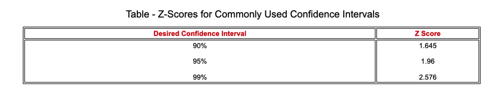

image: Boston University

## Confidence Level Example

A researcher wants to estimate the average number of hours per week spent by employees in a certain company on remote work activities.

They take a random sample of 80 employees and find that the average number of hours spent on remote work per week in the sample is 12 hours, with a standard deviation of 2 hours.

Calculate the 95% confidence interval for the average number of hours spent on remote work activities per week by all employees in the company.

## Confidence Interval Example

#### 1) Find the z score

#### 2) Add known values to equation

#### 3) Calculate the SE or $$\frac{s}{\sqrt{n}}$$

#### 4) Multiple value from step 3 by our z value

#### 5) Subtract that from our $\bar{x}$ for our Lower Bound CI

#### 6) Add that from our $\bar{x}$ for our Upper Bound CI

$$\text{CI} = \bar{x} \pm z \frac{s}{\sqrt{n}}$$

- 95% CI: 11.5613 $\leq$ $\bar{x}$ $\leq$ 12.4387

## Confidence Interval for Small Samples

With smaller samples (n< 30) the Central Limit Theorem does not apply,so we use a different distribution called the t distribution.

In order to locate our t-value, we have to locate the degrees of freedom.

## Degrees of Freedom

The number of independent values that are simple allowed to vary within the calculation of a parameter.

$$df = n - 1$$

n = sample size

But why n-1?

## n-1 with respect to Degrees of Freedom

Let’s consider an example where 4 people are asked to pick a number that, when combined with the other members, will equal 50.

- Person 1 chooses 10
- Person 2 chooses 20
- Person 3 chooses 10
- Person 4 chooses…… Oof they can’t choose anything! They are no longer free to vary.
- They have to choose 10 because the we want a sum that equals 50.

## Confidence Interval for Small Samples

Once we have a df and our confidence level, we head to page 373 in our book or head to this [link](https://www.sjsu.edu/faculty/gerstman/StatPrimer/t-table.pdf).

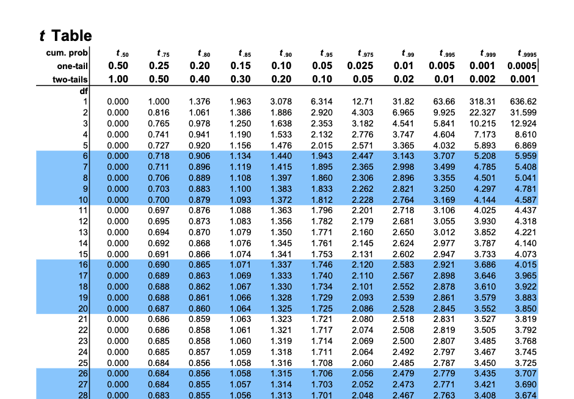

## Confidence Interval for Small Samples Example

A biology class wants to estimate the average length of a certain species of fish in a lake.

They take a random sample of 15 fish and measure their lengths. The sample mean length is 30 cm, and the sample standard deviation is 4 cm.

Calculate the 95% confidence interval for the average length of this species of fish in the lake.

## Confidence Interval Example

#### 1) Find the df and our confidence interval and locate the t value

#### 2) Add known values to equation

#### 3) Calculate the SE or $$\frac{s}{\sqrt{n}}$$

#### 4) Multiple value from step 3 by our t value

#### 5) Subtract that from our $\bar{x}$ for our Lower Bound CI

#### 6) Add that from our $\bar{x}$ for our Upper Bound CI

$$\text{CI} = \bar{x} \pm t \frac{s}{\sqrt{n}}$$

- 95% CI: 27.781 $\leq$ $\bar{x}$ $\leq$ 32.219

## That’s all folks! Have a great weekend!

[figure not shown]

Image: giphy